# Lab #4

```python
%matplotlib inline
import numpy as np
import matplotlib
import matplotlib.pyplot as plt
import scipy
from scipy import stats
import h5py


#this sets the size of the plot to something useful
plt.rcParams["figure.figsize"] = (20,15)
```

```python
hf = h5py.File('gammaray_lab4.h5', 'r')
```

```python
data = np.array(hf.get('data'))
```

```python
hf.close()
```

```python
time = data[0,:]
solarphase = data[1,:]
earthlong = data[2,:]
pcounts = data[3,:]
```

# Problem 1.

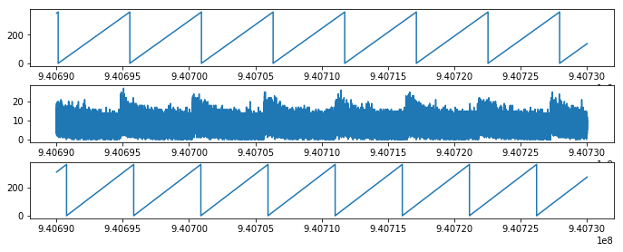

```python
plt.subplots_adjust(bottom=.2, top=1,
                    left=.01, right=1.5,
                    hspace=.35, wspace=.35)
plt.subplot(3,1,1)
plt.plot(time[100000:500000],earthlong[100000:500000])
plt.subplot(3,1,2)
plt.plot(time[100000:500000],pcounts[100000:500000])
plt.subplot(3,1,3)
plt.plot(time[100000:500000],solarphase[100000:500000]);
```

1 . As you can see, there is a recurring burst that appears in the time vs. particle count. These bursts occur approximately 5400 seconds apart, which is equal to one full 90 minute orbit. The plots above are of earth longitude, particle counts and solar phase vs time, respectively. With the middle graph, you can clearly see how the particle burst is related to the corresponding earth longitude and solar phase. These graphs were cut down to show about a 65th of the total data which allows us to see the patterns easily. The rest of the data follows this general pattern. This is signal contamination compared to the background.

Since the data follows a number of events per set interval, the distribution for the background particle counts is poisson. The resulting function would be a probability mass function, not density.

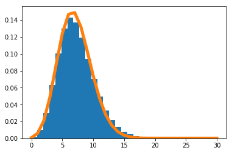

```python
fig1 = plt.figure(1)
plt.hist(pcounts,bins=31,density=True);
mean = np.mean(pcounts)
poss_counts = np.linspace(0,30,31)
plt.plot(poss_counts, stats.poisson.pmf(poss_counts,mean),linewidth=5);
```

This is a histogram of the raw particle count data. It can be seen that a poisson distribution with mean of approxiamtely 7 fits the data quite well.

3 . Using a burst/exponential decay function of: $${flux(time)} = A\exp(-\alpha t) $$ we can fill in the values to create a model for the background as a function of time. The only thing that changes with time is the time of the burst, which we can enter manually or via a loop.

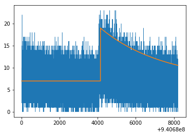

```python
def burst(x, b0, A1, T1, alpha1):
    """Burst model"""
    y = np.empty(x.shape)
    y.fill(b0)
    mask1 = (x >= T1)
    y[mask1] += A1 * np.exp(-alpha1 * (x[mask1] - T1))

    return y

zz = burst(time[0:82000]-9.4068e8,7,12,4150,.0003)

plt.plot(time[0:82000],pcounts[0:82000],linewidth=.5)
plt.plot(time[0:82000],zz);
```

Shown above is the fit model for a single burst, the following n bursts occur at about n*5400 seconds later.

4 . Since the background is not exactly time dependent as it is phase dependent, we will use different solar phases as our values for different 5-sigma measurements.

```python
# 5 sigma at phase = 315 degrees
sig1 = stats.norm.cdf(5)
avg1 = np.mean(pcounts[100:200])
print('The value for 5 sigma at a solar phase of 315 degrees is ' +str(stats.poisson.ppf(sig1,avg1)))
```

```
The value for 5 sigma at a solar phase of 315 degrees is 25.0
```

```python
avg2 = np.mean(pcounts[9000:9100])
print('The value for 5 sigma at a solar phase of 19 degrees is ' +str(stats.poisson.ppf(sig1,avg2)))
```

```
The value for 5 sigma at a solar phase of 19 degrees is 23.0
```

```python
avg3 = np.mean(pcounts[41700:41800])
print('The value for 5 sigma at a solar phase of 251 degrees is ' +str(stats.poisson.ppf(sig1,avg3)))
```

```
The value for 5 sigma at a solar phase of 251 degrees is 30.0
```

# Problem 2.

```python
im = h5py.File('images.h5', 'r')
```

```python
imdata = np.array(im.get('imagestack'))
```

1 . Plotting the images

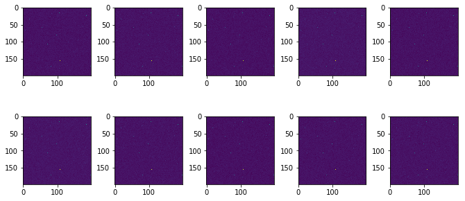

```python
plt.subplots_adjust(bottom=.05, top=1,
                    left=.05, right=1.5,
                    hspace=.35, wspace=.35)
plt.subplot(2,5,1)
plt.imshow(imdata[0:199,0:199,0]);
plt.subplot(2,5,2)
plt.imshow(imdata[0:199,0:199,1]);
plt.subplot(2,5,3)
plt.imshow(imdata[0:199,0:199,2]);
plt.subplot(2,5,4)
plt.imshow(imdata[0:199,0:199,3]);
plt.subplot(2,5,5)
plt.imshow(imdata[0:199,0:199,4]);
plt.subplot(2,5,6)
plt.imshow(imdata[0:199,0:199,5]);
plt.subplot(2,5,7)
plt.imshow(imdata[0:199,0:199,6]);
plt.subplot(2,5,8)
plt.imshow(imdata[0:199,0:199,7]);
plt.subplot(2,5,9)
plt.imshow(imdata[0:199,0:199,8]);
plt.subplot(2,5,10)
plt.imshow(imdata[0:199,0:199,9]);
```

2 . There doesn't seem to be much signal contamination apart from the few stars seen throughout the images. The background is not really time independent as it does not change as a function of time, there will always be that absence of light (at least for a while). It is pretty consistent spatially, so I'm going to go with a normal distribution for the pdf of the background. By averaging each image's pixel value, then averaging those 10 values I will get a good estimate of the average background value to use to create a normal distribution pdf.

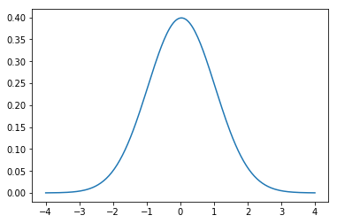

```python
avg = np.zeros(10)
for i in range(0,10):
    avg[i] = np.mean(imdata[0:199,0:199,i])
ov_avg = np.mean(avg)
x = np.linspace(-4,4,201)
pdf = stats.norm.pdf(x,ov_avg)
plt.plot(x,pdf);
```

Subtracting the average from all the images should only leave large values left greater than zero for supernovae or other bright events to be visible. Whichever images have the largest values in any pixel clearly have an event occuring in them. By comparing that measurement value to a sigma, significance can be claimed or the measurement can be discarded.

```python
maxs = np.zeros(10)
for u in range(0,10):
    maxs[u] = (imdata[0:199,0:199,u]-ov_avg).max()
print(maxs)
```

```
[45.97806656 46.55858093 47.75642206 46.04743446 46.96670043 46.58762989
 46.95763229 47.22956326 46.45470821 47.17928266]
```

3 . Image 3 has the largest value remaining after subtracting the mean (which is basically the background), therefore the supernova is located in that image. Averaging the largest values in all the images gives another distribution for the brighter data, shown below.

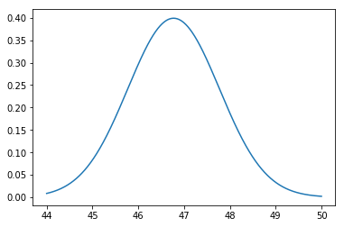

```python
bavg = np.mean(maxs)
xvals = np.linspace(44,50,1000)
bpdf = stats.norm.pdf(xvals,bavg)
plt.plot(xvals,bpdf);
```

4 . The final pdfs were different since we were both looking at differnt bounds of the background. He was looking for very small values in the image while I was looking for large values. The averages we used in our distributions were based around differnt local values.